# データ分析と線形代数03

UPDATE: 2021-09-24 23:14:01

# はじめに

ここでは[データ分析のための線形代数](https://www.kyoritsu-pub.co.jp/bookdetail/9784320018594)の章末問題をRで回答していきます。

- [データ分析のための線形代数](https://www.kyoritsu-pub.co.jp/bookdetail/9784320018594)

# 表1.1が表すアンケートデータ

```r
D <- matrix(c(1,3,1,1,4,5,26,
              1,2,1,3,1,3,22,
              2,3,1,1,1,5,27,
              1,2,2,1,1,5,34,
              1,2,2,2,3,2,28,
              3,4,1,1,3,5,20,
              4,1,2,3,4,4,18,
              4,4,1,2,4,4,30,
              2,3,2,4,2,4,23,
              1,2,2,1,4,1,32),
            nrow = 10, ncol = 7, byrow = TRUE)
colnames(D) <- paste0("Q", 1:7)
rownames(D) <- paste0("ID", 1:10)

# 1.1のアンケートデータ
D
```

```
##      Q1 Q2 Q3 Q4 Q5 Q6 Q7
## ID1   1  3  1  1  4  5 26
## ID2   1  2  1  3  1  3 22
## ID3   2  3  1  1  1  5 27
## ID4   1  2  2  1  1  5 34
## ID5   1  2  2  2  3  2 28
## ID6   3  4  1  1  3  5 20
## ID7   4  1  2  3  4  4 18
## ID8   4  4  1  2  4  4 30
## ID9   2  3  2  4  2  4 23
## ID10  1  2  2  1  4  1 32
```

# 3章の章末問題

## 3.1 以下のベクトルがあるとき、1から10の2つのベクトルが直交するかどうかを答えよ。ただし、2つのベクトルの間で、直交性が定義されていない場合は「定義されていない」と答えること。

$$\begin{eqnarray}
\boldsymbol{ s }
=\left(\begin{array}{c}
2 \\
1.5
\end{array}\right),
\boldsymbol{ t }
=\left(\begin{array}{c}
5 \\
2
\end{array}\right),
\boldsymbol{ v }
=\left(\begin{array}{c}
-3 \\
4
\end{array}\right),
\boldsymbol{ w }
=\left(\begin{array}{c}
0 \\
0
\end{array}\right),
\boldsymbol{ a }
=\left(\begin{array}{c}
2 \\
-5 \\
0
\end{array}\right),
\boldsymbol{ b }
=\left(\begin{array}{c}
3 \\
5 \\
-1
\end{array}\right),
\boldsymbol{ c }
=\left(\begin{array}{c}
-5 \\
3 \\
0
\end{array}\right),
\boldsymbol{ d }
=\left(\begin{array}{c}
0 \\
0 \\
7
\end{array}\right)
\end{eqnarray}$$

```r
s <- c(2, 1.5)
t <- c(5, 2)
v <- c(-3, 4)
w <- c(0, 0)
a <- c(2, -5, 0)
b <- c(3, 5, -1)
c <- c(-5, 3, 0)
d <- c(0, 0, 7)
```

### 3.1.1 sとt

```r
# 直交しない
s %*% t
```

```
##      [,1]
## [1,]   13
```

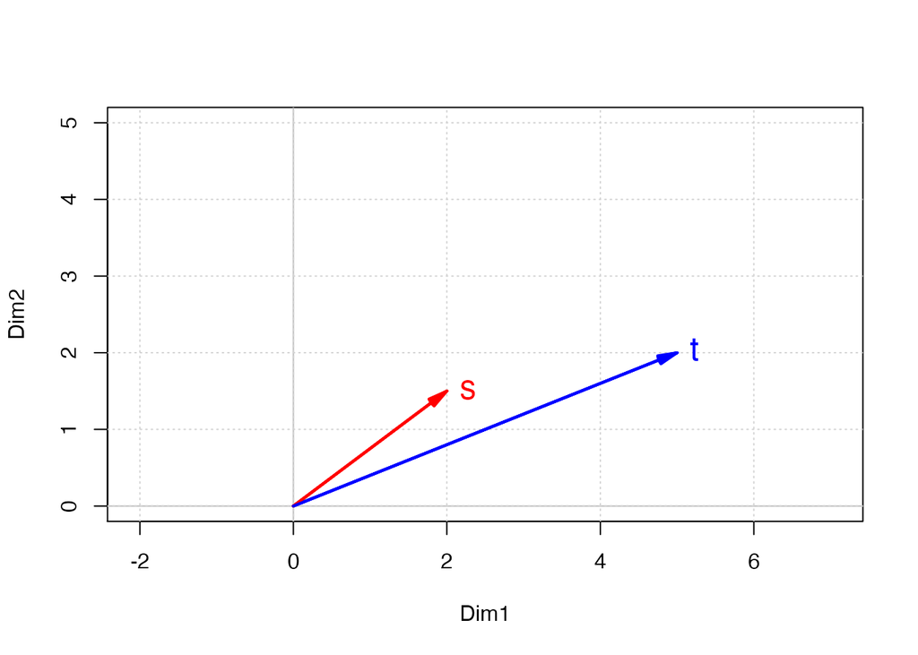

```r
library(matlib)
xlim <- c(0, 5)
ylim <- c(0, 5)
plot(xlim, ylim, type = "n", xlab = "Dim1", ylab = "Dim2", asp = 1)
abline(v = 0, h = 0, col = "gray")
grid()
vectors(rbind(s, t), col = c("red", "blue"))
```

### 3.1.2 vとs

```r
# 直交する
v %*% s
```

```
##      [,1]
## [1,]    0
```

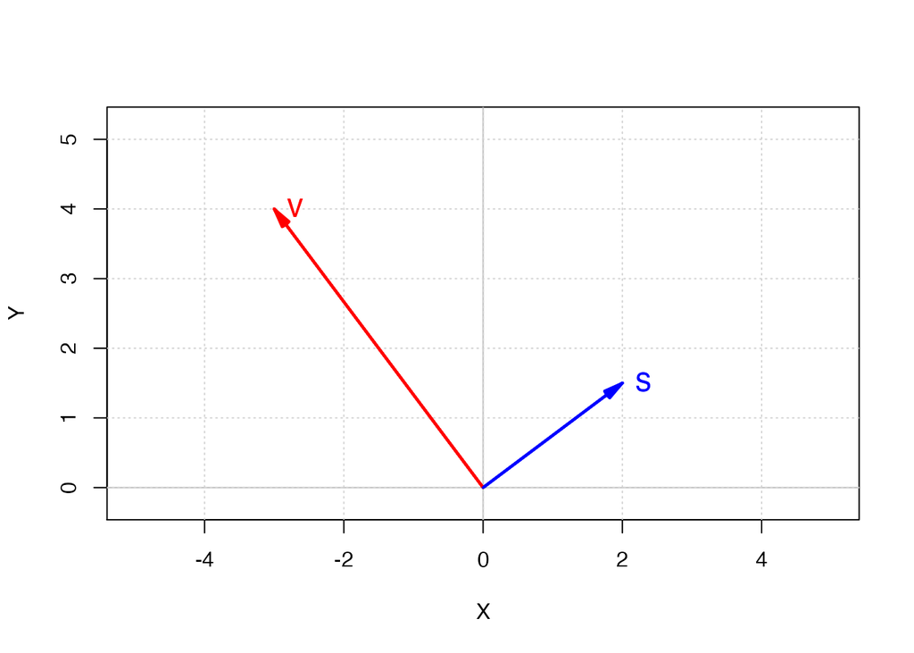

```r
xlim <- c(-5, 5)
ylim <- c(0, 5)
plot(xlim, ylim, type = "n", xlab = "X", ylab = "Y", asp = 1)
abline(v = 0, h = 0, col = "gray")
grid()
vectors(rbind(v, s), col = c("red", "blue"))
```

### 3.1.3 tとw

```r
# 直交する
t %*% w
```

```
##      [,1]
## [1,]    0
```

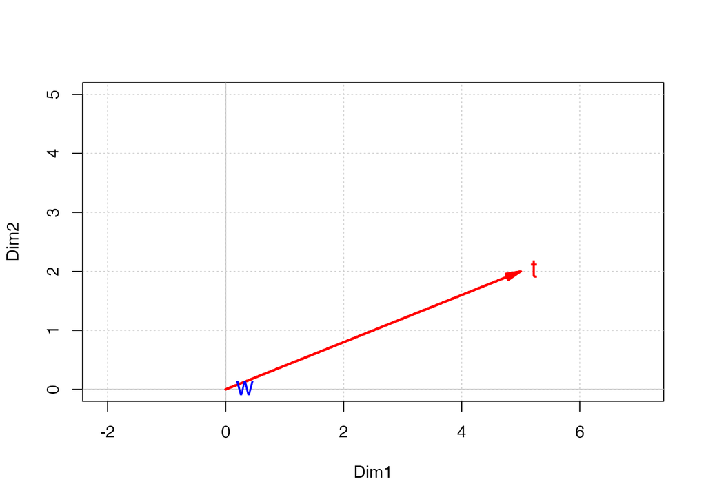

```r
xlim <- c(0, 5)
ylim <- c(0, 5)
plot(xlim, ylim, type = "n", xlab = "Dim1", ylab = "Dim2", asp = 1)
abline(v = 0, h = 0, col = "gray")
grid()
vectors(rbind(t, w), col = c("red", "blue"))
```

### 3.1.4 vとt

```r
# 直交しない
v %*% t
```

```
##      [,1]
## [1,]   -7
```

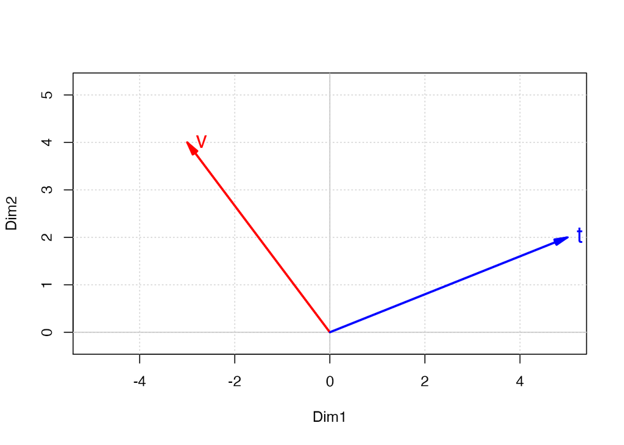

```r
xlim <- c(-5, 5)
ylim <- c(0, 5)
plot(xlim, ylim, type = "n", xlab = "Dim1", ylab = "Dim2", asp = 1)
abline(v = 0, h = 0, col = "gray")
grid()
vectors(rbind(v, t), col = c("red", "blue"))
```

### 3.1.5 tとa

```r
# 定義されない
```

### 3.1.6 cとd

```r
# 直交する
c %*% d
```

```
##      [,1]
## [1,]    0
```

### 3.1.7 bとc

```r
# 直交する
b %*% c
```

```
##      [,1]
## [1,]    0
```

### 3.1.8 bとa

```r
# 直交しない
b %*% a
```

```
##      [,1]
## [1,]  -19
```

### 3.1.9 wとd

```r
# 定義されない
```

### 3.1.10 dとa

```r
# 直交する
d %*% a
```

```
##      [,1]
## [1,]    0
```

## 3.2 1から12のベクトルの組が各々一次独立か一次従属かを答えよ。一次独立が定義されていない場合は「定義されていない」と答えること。

$$\begin{eqnarray}
(1)
\left(\begin{array}{c}
0 \\
0
\end{array}\right),
(2)
\left(\begin{array}{c}
-4 \\
-3
\end{array}\right),
(3)
\left(\begin{array}{c}
1 \\
4
\end{array}\right),
\left(\begin{array}{c}
-4 \\
1
\end{array}\right),
(4)
\left(\begin{array}{c}
1 \\
4
\end{array}\right),
\left(\begin{array}{c}
-2 \\
-8
\end{array}\right),
(5)
\left(\begin{array}{c}
1 \\
4
\end{array}\right),
\left(\begin{array}{c}
-4 \\
1
\end{array}\right),
\left(\begin{array}{c}
3 \\
-3
\end{array}\right),
(6)
\left(\begin{array}{c}
-3 \\
2 \\
-2
\end{array}\right),
\left(\begin{array}{c}
2 \\
0 \\
1
\end{array}\right)
(7)
\left(\begin{array}{c}
-3 \\
2 \\
-2
\end{array}\right),
\left(\begin{array}{c}
2 \\
0 \\
1
\end{array}\right),
\left(\begin{array}{c}
1 \\
-2 \\
1
\end{array}\right), \\
(8)
\left(\begin{array}{c}
-3 \\
2 \\
-2
\end{array}\right),
\left(\begin{array}{c}
2 \\
0 \\
1
\end{array}\right),
\left(\begin{array}{c}
0 \\
0 \\
0
\end{array}\right),
(9)
\left(\begin{array}{c}
1 \\
4
\end{array}\right),
\left(\begin{array}{c}
1 \\
0 \\
0
\end{array}\right),
(10)
\left(\begin{array}{c}
4 \\
5 \\
0
\end{array}\right),
\left(\begin{array}{c}
2 \\
1 \\
2
\end{array}\right),
\left(\begin{array}{c}
3 \\
-2 \\
1
\end{array}\right),
(11)
\left(\begin{array}{c}
4 \\
5 \\
0
\end{array}\right),
\left(\begin{array}{c}
2 \\
1 \\
2
\end{array}\right),
\left(\begin{array}{c}
3 \\
-2 \\
1
\end{array}\right),
\left(\begin{array}{c}
1 \\
-1 \\
1
\end{array}\right),
(12)
\left(\begin{array}{c}
1.5 \\
-1 \\
1
\end{array}\right),
\left(\begin{array}{c}
-3 \\
2 \\
-2
\end{array}\right),
\left(\begin{array}{c}
6 \\
-4 \\
4
\end{array}\right)
\end{eqnarray}$$
### 3.2.1 ゼロベクトル1つの組であり一次従属

### 3.2.2

非ゼロベクトル1つの組であり一次独立

### 3.2.3

一方が他方のスカラ倍ではなく一次独立

### 3.2.4

$$-2
\left(\begin{array}{c}
1 \\
4
\end{array}\right)
=
\left(\begin{array}{c}
-2 \\
-8
\end{array}\right)$$
であり一次従属。

### 3.2.5

2次ベクトル3つからなる組であり、一次従属

### 3.2.6

一方が他方のスカラ倍ではなく一次独立

### 3.2.7

$$\left(\begin{array}{c}
−3 \\
2 \\
-2
\end{array}\right)
= -
\left(\begin{array}{c}
2 \\
0 \\
1
\end{array}\right) -
\left(\begin{array}{c}
1 \\
-2 \\
1
\end{array}\right)$$
であり一次従属。

### 3.2.8

ゼロベクトルを含む組であり一次従属

### 3.2.9

定義されない

### 3.2.10

ランクが3であるため、一次独立。

```r
m <- matrix(
  c(4, 2, 3,
    5, 1,-2,
    0, 2, 1),
  nrow = 3,
  ncol = 3,
  byrow = TRUE
)

R(m)
```

```
## [1] 3
```

### 3.2.11

3次ベクトル4つからなる組であり一次従属。

### 3.2.12

ランクが1であるため、一次従属。

```r
m <- matrix(
  c(1.5,-3, 6,-1, 2,-4,
    1,-2, 4),
  nrow = 3,
  ncol = 3,
  byrow = TRUE
)

R(m)
```

```
## [1] 1
```

## 3.3 問題3.2の1から12について一次独立なベクトルの最大個数を求めよ。

この問題の回答は行なわない。

## 3.4 以下のベクトルについて、1から5に答えよ。

$$\begin{eqnarray}
\boldsymbol{ a }
=\left(\begin{array}{c}
2 \\
2
\end{array}\right),
\boldsymbol{ b }
=\left(\begin{array}{c}
-1 \\
-1
\end{array}\right),
\boldsymbol{ c }
=\left(\begin{array}{c}
-3 \\
4
\end{array}\right),
\boldsymbol{ d }
=\left(\begin{array}{c}
-1 \\
6
\end{array}\right),
\boldsymbol{ f }
=\left(\begin{array}{c}
3 \\
-4
\end{array}\right),
\boldsymbol{ g }
=\left(\begin{array}{c}
0 \\
0
\end{array}\right)
\end{eqnarray}$$

### 3.4.1 E1を張る3つのベクトルからなる組を6つのベクトルから選べ。

$\boldsymbol{a},\boldsymbol{b},\boldsymbol{g}$または$\boldsymbol{c},\boldsymbol{f},\boldsymbol{g}$。

### 3.4.2 E1を張る2つのベクトルからなる組を6つのベクトルから選べ。ただしゼロベクトルを含まないものとする。

$\boldsymbol{a},\boldsymbol{b}$または$\boldsymbol{c},\boldsymbol{f}$。

### 3.4.3 fを含むE2の基底を6つのベクトルから選べ。

$\boldsymbol{f},\boldsymbol{a}$、$\boldsymbol{f},\boldsymbol{b}$、$\boldsymbol{f},\boldsymbol{d}$。

### 3.4.4 E2の規定となる2つのベクトルからなる組を、6つのベクトルから選べ。ただし、bを含まないこと。

$\boldsymbol{a},\boldsymbol{c},\boldsymbol{d},\boldsymbol{f}$から選んだ2つのベクトルの組み合わせ、ただし、$\boldsymbol{c},\boldsymbol{f}$の組み合わせは除く。

### 3.4.5 ベクトルあを含む2つのベクトルからなるベクトルの組で、一次従属な組を2組選べ。

$\boldsymbol{a},\boldsymbol{b}$および$\boldsymbol{a},\boldsymbol{g}$。